**Question 1**

```r
library(resampledata)
```

```r
library(mosaic)
```

**Q1. a.**

```r
tail(NCBirths2004, 4)
```

|  | ID | MothersAge | Tobacco | Alcohol | Gender | Weight | Gestation | Smoker |
| --- | --- | --- | --- | --- | --- | --- | --- | --- |
| 1006 | 1006 | 20-24 | No | No | Male | 2835 | 39 | No |
| 1007 | 1007 | 15-19 | No | No | Male | 3260 | 38 | No |
| 1008 | 1008 | 20-24 | No | No | Female | 2637 | 41 | No |
| 1009 | 1009 | 20-24 | No | No | Female | 3005 | 39 | No |

```r
#data.frame(table(NCBirths2004$Tobacco))
data.frame(table(NCBirths2004$Smoker))
```

| Var1 | Freq |
| --- | --- |
| No | 898 |
| Yes | 111 |

```r
#dfno = NCBirths2004[NCBirths2004$Smoker == 'No', ]
#dfyes = NCBirths2004[NCBirths2004$Smoker == 'Yes', ]
#tail(dfyes, 4)
#tail(dfno, 4)
favstats(~Weight|Smoker, data=NCBirths2004)
```

| Smoker | min | Q1 | median | Q3 | max | mean | sd | n | missing |
| --- | --- | --- | --- | --- | --- | --- | --- | --- | --- |
| No | 2013 | 3147 | 3459 | 3771.0 | 5131 | 3471.912 | 478.5524 | 898 | 0 |
| Yes | 1928 | 2948 | 3204 | 3529.5 | 4649 | 3256.910 | 520.4788 | 111 | 0 |

```r
#favstats(~Weight, data=dfyes)
nsims = 1000 #the number of simulations
n.Yes = favstats(~Weight|Smoker, data=NCBirths2004)$n[2]
n.No = favstats(~Weight|Smoker, data=NCBirths2004)$n[1]
#n.Yes
#n.No

mean.NonSmoke = numeric(nsims)
mean.YesSmoke = numeric(nsims)
diffmeans = numeric(nsims)
No = filter(NCBirths2004, Smoker == 'No')
Yes = filter(NCBirths2004, Smoker == 'Yes')

for(i in 1:nsims)
{   mean.NonSmoke[i] = mean(sample(No$Weight, n.No, replace=TRUE))
    mean.YesSmoke[i] = mean(sample(Yes$Weight, n.Yes, replace=TRUE))
    diffmeans[i] = mean.NonSmoke[i] - mean.YesSmoke[i]
}
boot.diffmeans = data.frame(mean.NonSmoke, mean.YesSmoke, diffmeans)
head(boot.diffmeans, 3)
```

|  | mean.NonSmoke | mean.YesSmoke | diffmeans |
| --- | --- | --- | --- |
| 1 | 3500.448 | 3310.613 | 189.8350 |
| 2 | 3482.824 | 3313.387 | 169.4367 |
| 3 | 3471.915 | 3222.378 | 249.5370 |

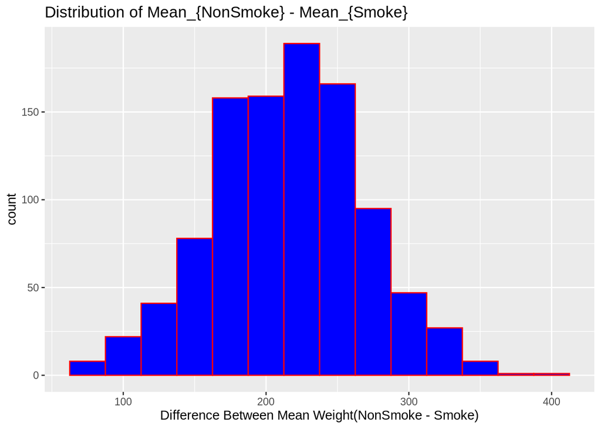

```r
ggplot(data=boot.diffmeans, aes(x = diffmeans)) + geom_histogram(fill='blue', col='red', binwidth=25) + xlab("Difference Between Mean Weight(NonSmoke - Smoke)") + ggtitle("Distribution of Mean_{NonSmoke} - Mean_{Smoke}")
```

**Q1. b.**

```r
qdata(~ diffmeans, c(0.025, 0.975), data=boot.diffmeans)
```

```
##     2.5%    97.5%
## 110.3147 317.1454
```

**Q1. c.**

```r
t.test(~Weight|Smoker, data=NCBirths2004, conf.level = 0.95, var.equal=FALSE)  #provides the df and the CI
```

```
##
##  Welch Two Sample t-test
##
## data:  Weight by Smoker
## t = 4.1411, df = 134.01, p-value = 6.08e-05
## alternative hypothesis: true difference in means between group No and group Yes is not equal to 0
## 95 percent confidence interval:
##  112.3161 317.6881
## sample estimates:
##  mean in group No mean in group Yes
##          3471.912          3256.910
```

From my result, the 95% Confidence Interval using the t-version is $112.3161 \leq \mu_{NonSmoke} - \mu_{Smoke} \leq 317.6881$

**Q1. d.** I can infer that, children born to birth mother who did not smoke during pregnancy weigh more on average than babies born to birth mothers who did smoke during pregnancy, as the $\mu_{NonSmoke} - \mu_{Smoke}$ falls in confidence intervals that both upper bound and lower bound are positive.

**Q2. a.**

```r
nsims = 2000
sd.NonSmoke = numeric(nsims)
sd.YesSmoke = numeric(nsims)
ratiosd = numeric(nsims)

for(i in 1:nsims)
{   sd.NonSmoke[i] = sd(sample(No$Weight, n.No, replace=TRUE))
    sd.YesSmoke[i] = sd(sample(Yes$Weight, n.Yes, replace=TRUE))
    ratiosd[i] = sd.NonSmoke[i] / sd.YesSmoke[i]
}
boot.ratiosd = data.frame(sd.NonSmoke, sd.YesSmoke, ratiosd)
head(boot.ratiosd, 3)
```

|  | sd.NonSmoke | sd.YesSmoke | ratiosd |
| --- | --- | --- | --- |
| 1 | 490.8892 | 496.9049 | 0.9878936 |
| 2 | 479.2890 | 504.0245 | 0.9509241 |
| 3 | 483.9352 | 475.1571 | 1.0184742 |

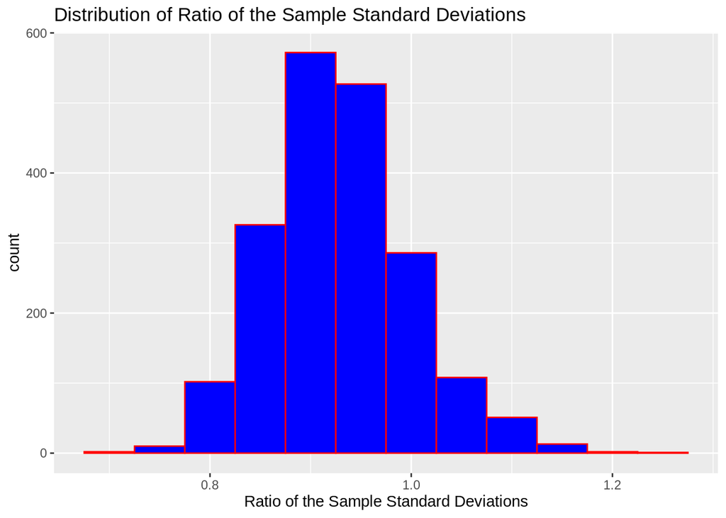

```r
ggplot(data=boot.ratiosd, aes(x = ratiosd)) + geom_histogram(fill='blue', col='red', binwidth=0.05) + xlab("Ratio of the Sample Standard Deviations") + ggtitle("Distribution of Ratio of the Sample Standard Deviations")
```

**Q2. b**

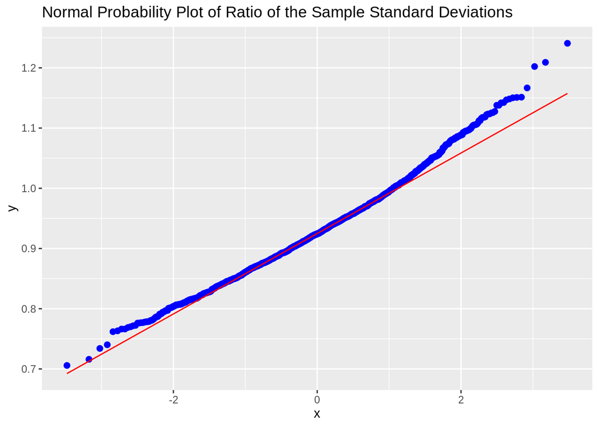

```r
ggplot(data=boot.ratiosd, aes(sample = ratiosd)) + stat_qq(size=2, col='blue') + stat_qq_line(col='red') + ggtitle("Normal Probability Plot of Ratio of the Sample Standard Deviations")
```

```r
#As the plot shows, the ratio of the sample standard deviations appear to follow a Normal distribution.
```

**Q2. c**

```r
qdata(~ ratiosd, c(0.025, 0.975), data=boot.ratiosd)
```

```
##      2.5%     97.5%
## 0.8064415 1.0859421
```

**Q3 .a**

If mercury levels in walleye fish harvested from the Athabaska River (downstream of Whitecourt) exceed Heath Canada’s action level, then on average, $mu_{m} > 1$. If not, on average, $\mu{m} \leq 1$. The following are statistical hypotheses:

$$\begin{eqnarray}
{\rm H}_{0}: \mu_{m} & \leq (= ) & 1 \hspace{0.2in} \text{(the
mean of mercury levels from sampling walleyes did not exceed Heath
Canada’s action level)} \\
{\rm H}_{a}: \mu_{m} & > & 1 \hspace{0.2in} \text{(the mean
of mercury levels from sampling walleyes exceed Heath Canada’s action
level)} \\
\end{eqnarray}$$

**Q3. b.** In the context of my statistical hypotheses in part a, The Type I Error should be that, when the mean mercury (in ppm) of walleye found downstream from Whitecourt did not exceed Heath Canada’s action level, we make a decision to conclude that the mean mercury exceed. In a other word, When the null hypothesis is True, Reject the null hypothesis. The Type II Error should be that, when the mean of mercury levels from sampling walleyes exceed Heath Canada’s action level, I make a decision to conclude that the mean mercury did not exceed. In a other word, When the null hypothesis is False, Fail to Reject the null hypothesis.

**Q3 c**

```r
mercury.data = data.frame(mercury = c(1.2,1.1,1.0,1.0,1.1,1.0,1.0,1.0,0.9,1.1,1.1,1.2,1.0,1.1,1.0, 1.1,1.0,0.9,1.0,1.0,1.1,1.0,1.0,1.1,1.2,1.0,1.1,1.0,1.0,1.2,1.1))
favstats(~mercury, data=mercury.data) #will compute various minutes arrive late statistics "conditional" upon airline name
```

|  | min | Q1 | median | Q3 | max | mean | sd | n | missing |
| --- | --- | --- | --- | --- | --- | --- | --- | --- | --- |
|  | 0.9 | 1 | 1 | 1.1 | 1.2 | 1.051613 | 0.08112118 | 31 | 0 |

```r
head(mercury.data)
```

|  | mercury |
| --- | --- |
| 1 | 1.2 |
| 2 | 1.1 |
| 3 | 1.0 |
| 4 | 1.0 |
| 5 | 1.1 |
| 6 | 1.0 |

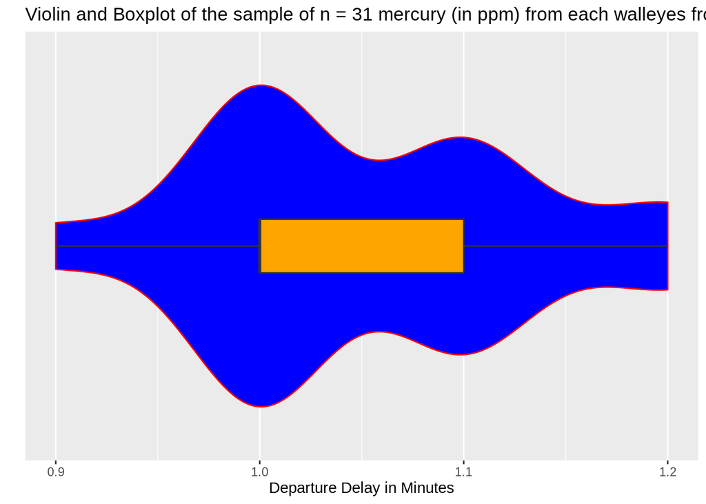

```r
ggplot(data=mercury.data, aes(x = "", y = mercury)) + geom_violin(col="red", fill="blue") + geom_boxplot(width=0.15, fill="orange", na.rm=TRUE) + xlab("") + ylab("Departure Delay in Minutes") + scale_x_discrete(breaks=NULL) + coord_flip() + ggtitle("Violin and Boxplot of the sample of n = 31 mercury (in ppm) from each walleyes from a recent commercial fishing catch downstream from Whitecourt")
```

**Q3 d.** These data does suggest that Health Canada should place a moritorium on commercial walleye fishing on the Athabaska River downstream of Whitecourt.

```r
#I set up The Alpha = 0.05
t.test(~ mercury, mu=1, alternative="greater", data=mercury.data)
```

```
##
##  One Sample t-test
##
## data:  mercury
## t = 3.5425, df = 30, p-value = 0.0006595
## alternative hypothesis: true mean is greater than 1
## 95 percent confidence interval:
##  1.026884      Inf
## sample estimates:
## mean of x
##  1.051613
```

```r
pvalue = 0.0006595 # 0.0006595 < 0.05
#p-value < Alpha
#Therefore, I reject the null hypothesis.
t.test(~mercury, data=mercury.data)$conf
```

```
## [1] 1.021857 1.081368
## attr(,"conf.level")
## [1] 0.95
```

```r
#A 95% confidence interval for the mean mercury (in ppm) of walleye found downstream from Whitecourt.
#Is [1.021857, 1.081368].
#In the given scenario, the p-value means that the area under the t-distribution where t > 3.5425.
#measures how far the test statistic from the H_0.
```

**Q4**

$$\begin{eqnarray}
{\rm H}_{0}: p & \leq (=) & \:0.60 \hspace{0.25in} {\rm
\text{(the proportion of certified coffee growers in Southern Mexico who
are either certified or in the process of being certified, is less or
equal than 60%)}} \\
{\rm H}_{0}: p & >& \:0.60 \hspace{0.25in} {\rm \text{(the
proportion of certified coffee growers in Southern Mexico who are either
certified or in the process of being certified, is more than 60%)}} \\
\end{eqnarray}$$

```r
Xcertified = 475 +75
Xcertified
```

```
## [1] 550
```

The Distribution of the Statistic $X_{Obs}$

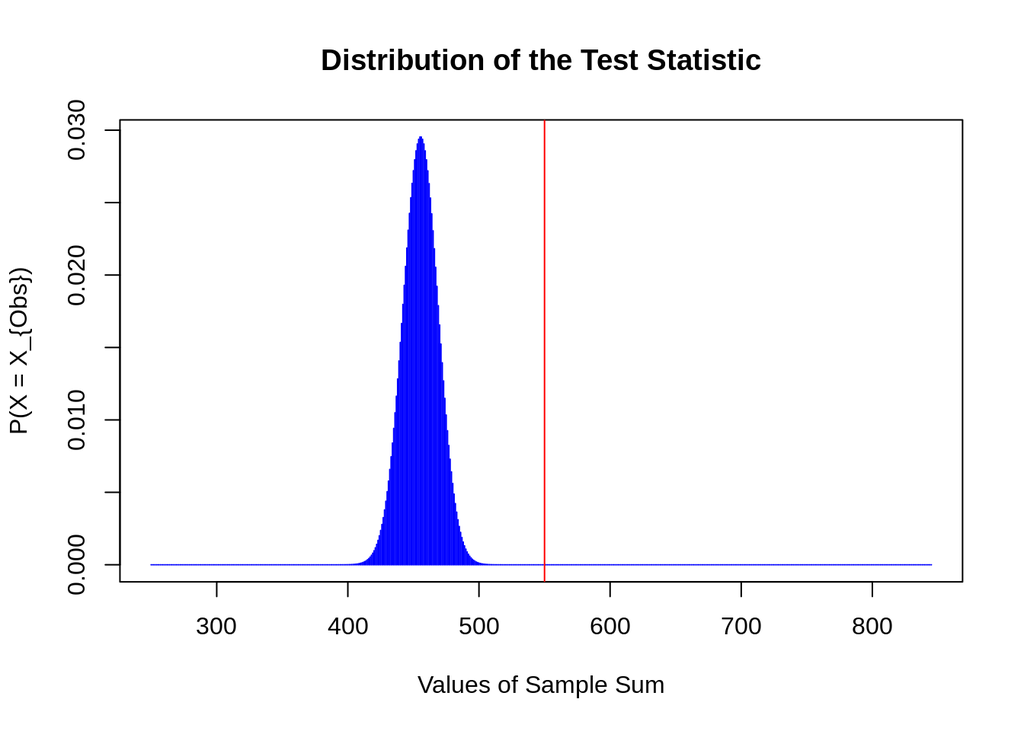

```r
plot(seq(250, 845, 1), dbinom(seq(250, 845, 1), 759, 0.60), xlab="Values of Sample Sum", ylab="P(X = X_{Obs})", type="h", col="blue", main="Distribution of the Test Statistic")
abline(v = 550, col="red")
```

Computation of the $P$-value. Under the assumption/condition that the null hypothesis ${\rm H}_{0}: p = 0.60$ is true, the $P$-value is

```r
pvalue.q4 <- 1 - pbinom(550, 845, 0.6) # computes P(X <= 550) with n = 845 and the incorporated assummed value of p = 0.6
pvalue.q4
```

```
## [1] 0.001045019
```

```r
#Reject H_0, as 0.001045019 < 0.05
```

Reject ${\rm H}_{0}$, as $0.001045019 < 0.05$

For a regulated value of $\alpha = 0.05$, the rejection region is

```r
qbinom(0.95, 845, 0.6)
```

```
## [1] 530
```

As a result, we have distrust in that assumption and the null hypothesis is rejected. As a result we conclude from these this sample, that $p > 0.60$, or that more than 60% of certified coffee growers in Southern Mexico who are either certified or in the process of being certified.

**Q5**

```r
prop.test(c( 348 + 1, 274 + 1), c(670+ 2, 376 + 2), correct=FALSE)
```

```
##
##  2-sample test for equality of proportions without continuity
##  correction
##
## data:  c out of c348 + 1 out of 670 + 2274 + 1 out of 376 + 2
## X-squared = 43.479, df = 1, p-value = 4.284e-11
## alternative hypothesis: two.sided
## 95 percent confidence interval:
##  -0.266833 -0.149503
## sample estimates:
##    prop 1    prop 2
## 0.5193452 0.7275132
```

From the result, it shows that difference between two population proportions are negative.
$$-0.266833 \leq p_{hs} - p_{uni} \leq -0.149503
\\p_{hs} < p_{uni}$$
It means that the proportion of persons with at most a high school education who disagree the science around vaccinations isn’t greater than the similar proportion of persons with at least an undergraduate university degree The proportion of persons with at most a high school education who disagree the science around vaccinations is less than the similar proportion of persons with at least an undergraduate university degree.

**Q6. a**

$$\begin{eqnarray}
{\rm H}_{0}: p & \leq & 0.45 \hspace{0.2in} \text{(do not run
for office)} \\
{\rm H}_{A}: p & > & 0.45 \hspace{0.2in} \text{(run for
office)} \\
\end{eqnarray}$$

**Q6 b**

The null hypothesis in (a) is rejected if this count X is greater than or equal to 20. That is, Reject ${\rm H}_{0}$ if $X≥20$. Compute the value of $\alpha$:

```r
#Given that you have decided that there is enough statistical
#evidence to support the “mimimum of 45%”-claim if out of n=50 randomly
#chosen voters, at least 20 indicate they will vote for
#this candidate if they run.
#Therefore, The X is set to be 20.

#qbinom(0.95, 50, 0.45)
#1 - pbinom(28, 50, 0.45)
alpha6 = sum(dbinom(20:50, 50, 0.45))
alpha6
```

```
## [1] 0.8026321
```

**Q6. c**

```r
#I think the creator of the question wants us to compute the Type II Error here.

#It is the Type II Error if and only if the statistical hypotheses set to be
#H_0 is P >= 0.45, H_a is p < 0.45.

#However, I set up my statistical hypotheses as H_0: p<= 0.45, H_a: p >0.45
#This makes the part c becomes that, when H_0 is Ture, Reject H_0,
#which is a Type I Error.

#From what I learn in the lecture, There is no wrong setting up for
#the statistical hypotheses as long as the following steps can make sense.
#And I am certain that my H_0 and H_a can carry out the Hypothesis Testing
#with no problem.

#Therefore, it is not my fault that part c, d and e makes less sense under
#the statistical hypotheses I came up with.

probc = sum(dbinom(20:50, 50, 0.42))
probc
```

```
## [1] 0.663807
```

```r
#1 - pbinom(19, 50, 0.42)
#The probability that you will conclude they should run for office,
#if the candidate were to receive 42% of the vote.

#This is the probability that If H_0 is true, Reject H_0.
#(in this case, H_0:p <= 0.45)
```

**Q6. d**

```r
#Refer to my thought in part c,
#those are probabilities of H_0 is true,Reject H_0,
#with different values of p <= 0.45
proportionofvote = c(0.41,0.40,0.39,0.38,0.35, 0.30)


proboutcomes = 1 - pbinom(19,50,proportionofvote)

df.proboutcomes <- data.frame(proportionofvote,proboutcomes)
head(df.proboutcomes)
```

|  | proportionofvote | proboutcomes |
| --- | --- | --- |
| 1 | 0.41 | 0.6099048 |
| 2 | 0.40 | 0.5535236 |
| 3 | 0.39 | 0.4957191 |
| 4 | 0.38 | 0.4376490 |
| 5 | 0.35 | 0.2735637 |
| 6 | 0.30 | 0.0848026 |

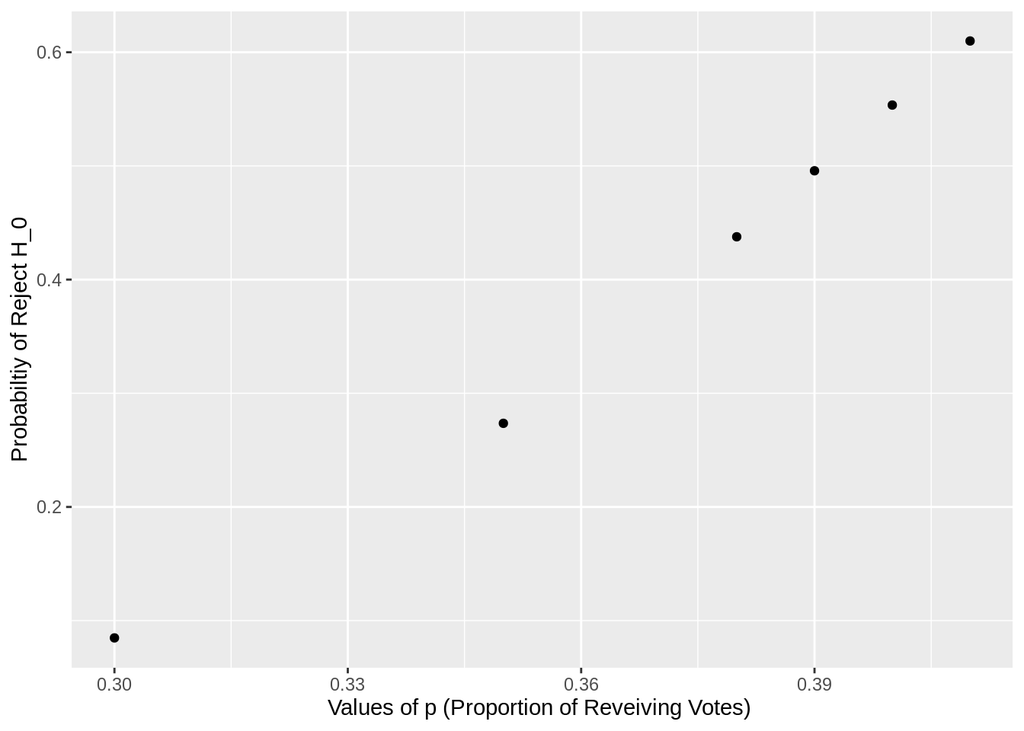

```r
ggplot(data=df.proboutcomes, aes(x = proportionofvote, y = proboutcomes)) + geom_point(fill="blue") + xlab("Values of p (Proportion of Reveiving Votes) ") + ylab("Probabiltiy of Reject H_0")
```

**Q6. e**

```r
#The graph in part (d) tells that the probability that
#I will conclude they should run for office
#is proportional to the value of p which are the proportion of vote received.
#In another word, as the the the candidate receives more votes,
#the probability of concluding that he should run for the office is increasing.


#As those are Type I Errors with different values of p <= 0.45,
#It means that the chance of making a Type I Error is very high,
#when the p value is approaching to the upper bound of H_0, where p = 0.45.
#In another word, The probability of Type I Error appearing is too high.

#The statistical test can be improved by changing the rejection region.
#For a regulated value of alpha = 0.05, the rejection region is x > 28
#And the value of alpha should be change to 0.04437937
#It insures that the statistical hypotheses is more accurate.
qbinom(0.95, 50, 0.45)
```

```
## [1] 28
```

```r
alphae = 1 - pbinom(28, 50, 0.45)
alphae
```

```
## [1] 0.04437937
```

$$\text{Reject the null hypothesis if} \:\: \{X_{Obs}: X > 28\}$$

**Q7. a**

```r
df.q7 = read.csv("http://people.ucalgary.ca/~jbstall/DataFiles/bookprices.csv")
#head(df.q7)
df.q7 = df.q7 %>%
  mutate(Diff = UsedBkStore - UsedAmazon) #create a new variable called Diff = price of camera at JR - price of same camera at BH
head(df.q7)
```

|  | UsedBkStore | UsedAmazon | Diff |
| --- | --- | --- | --- |
| 1 | 160.46 | 128.95 | 31.51 |
| 2 | 82.05 | 34.40 | 47.65 |
| 3 | 96.08 | 30.41 | 65.67 |
| 4 | 96.71 | 110.99 | -14.28 |
| 5 | 77.96 | 33.99 | 43.97 |
| 6 | 104.96 | 20.00 | 84.96 |

Given that these data were collected using a **Matched Pairs Experimental Design**, the difference is defined as

$$d_{i} = x_{UsedBkStore, i} - x_{UsedAmazon, i}$$

the statistical hypothesis to be tested is

$$\begin{eqnarray}
{\rm H}_{0}: \mu_{d} & \leq (= ) & 0 \hspace{0.2in} \text{(the
mean of a population of differences is at most equal to zero)} \\
{\rm H}_{A}: \mu_{d} & > & 0 \hspace{0.2in} \text{(the mean
of a population of differences is more than zero)} \\
\end{eqnarray}$$

I set up the $\alpha = 0.05$

```r
#Find p-value by using t.test
t.test(~Diff, mu=0, alternative="two.sided", data=df.q7)
```

```
##
##  One Sample t-test
##
## data:  Diff
## t = 3.0357, df = 14, p-value = 0.008898
## alternative hypothesis: true mean is not equal to 0
## 95 percent confidence interval:
##   7.474595 43.461405
## sample estimates:
## mean of x
##    25.468
```

```r
#p-value is 0.008898
```

Because $p-value < \alpha$, I Reject $H_{0}: \mu_{d} \leq(=) 0$. I conclude that the price of a used textbook at the University of Calgary Bookstore is more when compared to the price of a used text book on Amazon.ca.

**Q7. b** The inferences made about the mean different in the price of used textbooks between University of Calgary Bookstore and Amazon.ca are made upon the condition that the differences follow a Normal distribution/can be modeled by the Normal probability model.

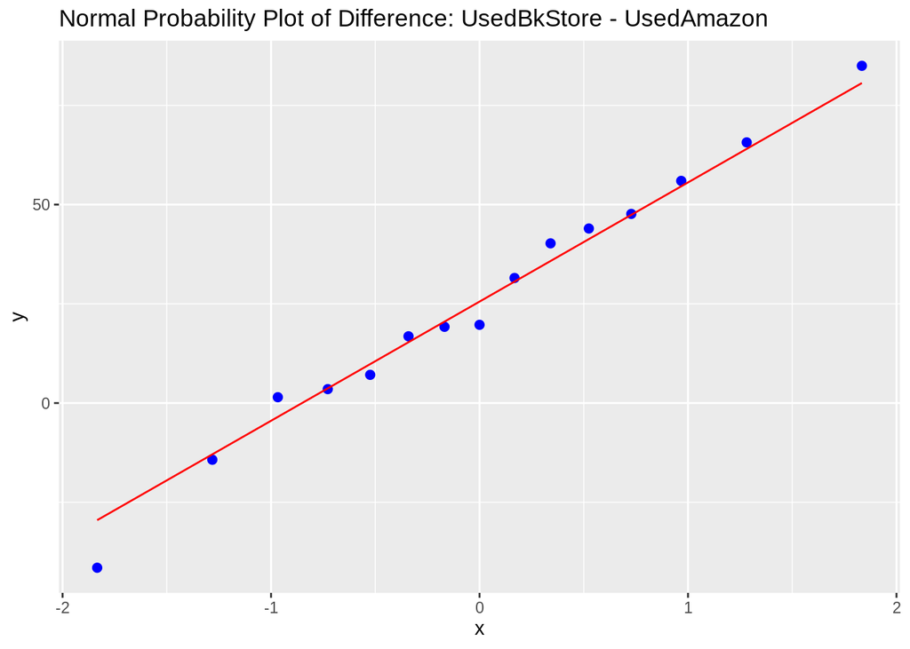

```r
ggplot(data=df.q7, aes(sample = Diff)) + stat_qq(size=2, col='blue') + stat_qq_line(col='red') + ggtitle("Normal Probability Plot of Difference: UsedBkStore - UsedAmazon")
```

```r
#As the plot shows this condition is satisfied.
```

**Q8** the statistical hypothesis to be tested is
$$\begin{eqnarray}
{\rm H}_{0}: p_{psd} & = & \:0.62 \hspace{0.25in} {\rm
\text{(the proportion of residents of a certain municipality is the same
as the provincial proportion)}} \\
{\rm H}_{0}: p_{psd} & \neq & \:0.62 \hspace{0.25in} {\rm
\text{(the proportion of residents of a certain municipality differs
from the provincial proportion)}} \\
\end{eqnarray}$$
I set up the $\alpha = 0.05$

Obtain a test statistic, a smaple of 250 randomly chosen adults yielded 145 completed some form of post-secondary education. X = 145 which is the test statistic. $n = 250$, $X_{Obs} = 145$

```r
#Calculate the p-value
binom.test(145, 250, 0.62, ci.method="plus4")
```

```
##
##  Exact binomial test (Plus 4 CI)
##
## data:  145 out of 250
## number of successes = 145, number of trials = 250, p-value = 0.1932
## alternative hypothesis: true probability of success is not equal to 0.62
## 95 percent confidence interval:
##  0.5180179 0.6394624
## sample estimates:
## probability of success
##                   0.58
```

The 95% Confidence Interval for $p_{psd}$ is:
$$0.5180179 \leq p_{psd} \leq 0.6394624$$
Where the $H_{0}$ falls in this Confidence Interval.

The $p_value = 0.1932$, $p_value >\alpha$. I Fail to Reject $H_{0}$.

Thus, I conclude that the proportion of residents of a certain municipality is the same as the provincial proportion.

In the context of these data, the p-value is the probability that another sample of n=250 randomly chosen adults aged 25 - 64 living in this municipality will yield more condemning evidence than the test statistic we have this time which is 145, assuming that the null hypothesis $p = 0.62$ is correct. Where the null hypothesis is the proportion of residents of a certain municipality is the same as the provincial proportion.

For a two tail test, p - value is the area under the binomial probability distribution curve values that far from the absolutely values of test statistic and the negative absolutely values of test statistic in both directions. Each area represents half of the p-value.

**Q9 a**

```r
n1 = 1000
x1 = 561
n2 = 1010
x2 = 601
prop.test(c(x1 + 1, x2 + 1), c(n1 + 2, n2 + 2), conf.level=0.95, correct=FALSE)$conf
```

```
## [1] -0.077100209  0.009133376
## attr(,"conf.level")
## [1] 0.95
```

The 95% Confidence Interval for $p_{2019} - p_{2012}$ is:
$$-0.077100209 \leq p_{2019} - p_{2012} \leq 0.009133376$$

**Q9 b** The result in part (a) shows that there is no statistically significant difference between $p_{2019}$ and $p_{2012}$. Because the difference between the proportion of Canadians who currently support a ban on single-use plastics and the proportion of Canadians who supported such a ban in 2012 falls in the interval [-0.077100209, 0.009133376]. Between a negative value and a positive value, it could happen if $p_{2019} - p_{2012} = 0$.